# Stimulus Valence

Kristina Kobrock

14 3 2022

# The role of affect in the Automatic Approach Bias: An empirical investigation.

## The effect of stimulus valence in the Affect-AAT

Load the preprocessed data (see DataAnalysis.Rmd for details).

```r
load("affect-aat.Rdata")
```

### Model with stimulus valence

```
##   subject_id trial condition mood_induction  log_RT_s pictures stimulus_valence
## 1          1     5 congruent       positive 1.4462897       72         negative
## 2          1     6 congruent       positive 0.6362078       62         negative
## 3          1     7 congruent       positive 2.3794958       46         negative
## 4          1     8 congruent       positive 0.6346828       84         negative
## 5          1     9 congruent       positive 1.0062967       17         positive
## 6          1    10 congruent       positive 2.0084809       30         positive
```

The same priors are used as in the main analysis. No group-level effects are added.

One simple model where stimulus_valence is added without interaction:

```r
summary(fit_stimulusModel, priors=TRUE)
```

```
##  Family: gaussian
##   Links: mu = identity; sigma = identity
## Formula: log_RT_s ~ condition * mood_induction + stimulus_valence
##    Data: df_aat_log1 (Number of observations: 28846)
##   Draws: 4 chains, each with iter = 2000; warmup = 1000; thin = 1;
##          total post-warmup draws = 4000
##
## Priors:
## b ~ normal(0, 10)
## Intercept ~ student_t(3, 0, 3)
## sigma ~ student_t(3, 0, 3)
##
## Population-Level Effects:
##                                             Estimate Est.Error l-95% CI
## Intercept                                      -0.02      0.01    -0.04
## conditionincongruent                            0.14      0.02     0.11
## mood_inductionpositive                         -0.02      0.02    -0.05
## stimulus_valencepositive                       -0.08      0.01    -0.10
## conditionincongruent:mood_inductionpositive    -0.02      0.02    -0.06
##                                             u-95% CI Rhat Bulk_ESS Tail_ESS
## Intercept                                       0.01 1.00     2740     3122
## conditionincongruent                            0.17 1.00     2189     2870
## mood_inductionpositive                          0.01 1.00     2057     2539
## stimulus_valencepositive                       -0.06 1.00     4963     3000
## conditionincongruent:mood_inductionpositive     0.03 1.00     1749     2399
##
## Family Specific Parameters:
##       Estimate Est.Error l-95% CI u-95% CI Rhat Bulk_ESS Tail_ESS
## sigma     1.00      0.00     0.99     1.00 1.00     6609     2296
##
## Draws were sampled using sampling(NUTS). For each parameter, Bulk_ESS
## and Tail_ESS are effective sample size measures, and Rhat is the potential
## scale reduction factor on split chains (at convergence, Rhat = 1).
```

The model output suggests something that I did not expect: a main effect of stimulus_valence, but a negative main effect suggesting that actually positive instead of negative reaction times are shorter.

I’m running a model with interaction and group-level effects to see whether this main effect is influenced by a specific condition in the experiment:

```
##  Family: gaussian
##   Links: mu = identity; sigma = identity
## Formula: log_RT_s ~ condition * mood_induction * stimulus_valence + (condition * mood_induction || subject_id)
##    Data: df_aat_log1 (Number of observations: 28846)
##   Draws: 4 chains, each with iter = 10000; warmup = 5000; thin = 1;
##          total post-warmup draws = 20000
##
## Priors:
## b ~ normal(0, 10)
## Intercept ~ student_t(5, -0.2, 1)
## sd ~ student_t(3, 0, 2)
## sigma ~ student_t(3, 0, 2)
##
## Group-Level Effects:
## ~subject_id (Number of levels: 95)
##                                                 Estimate Est.Error l-95% CI
## sd(Intercept)                                       0.66      0.05     0.57
## sd(conditionincongruent)                            0.28      0.02     0.23
## sd(mood_inductionpositive)                          0.46      0.04     0.40
## sd(conditionincongruent:mood_inductionpositive)     0.26      0.03     0.21
##                                                 u-95% CI Rhat Bulk_ESS Tail_ESS
## sd(Intercept)                                       0.76 1.00     3205     5364
## sd(conditionincongruent)                            0.33 1.00     8142    12937
## sd(mood_inductionpositive)                          0.54 1.00     5409    10193
## sd(conditionincongruent:mood_inductionpositive)     0.32 1.00     8711    12399
##
## Population-Level Effects:
##                                                                      Estimate
## Intercept                                                               -0.02
## conditionincongruent                                                     0.14
## mood_inductionpositive                                                   0.04
## stimulus_valencepositive                                                -0.03
## conditionincongruent:mood_inductionpositive                             -0.06
## conditionincongruent:stimulus_valencepositive                            0.01
## mood_inductionpositive:stimulus_valencepositive                         -0.12
## conditionincongruent:mood_inductionpositive:stimulus_valencepositive     0.07
##                                                                      Est.Error
## Intercept                                                                 0.07
## conditionincongruent                                                      0.03
## mood_inductionpositive                                                    0.05
```

[output cut: 43 more lines]

```
## conditionincongruent                                                    12188
## mood_inductionpositive                                                   7092
## stimulus_valencepositive                                                14655
## conditionincongruent:mood_inductionpositive                             14412
## conditionincongruent:stimulus_valencepositive                           14448
## mood_inductionpositive:stimulus_valencepositive                         15413
## conditionincongruent:mood_inductionpositive:stimulus_valencepositive    14333
##
## Family Specific Parameters:
##       Estimate Est.Error l-95% CI u-95% CI Rhat Bulk_ESS Tail_ESS
## sigma     0.75      0.00     0.74     0.75 1.00    30415    15084
##
## Draws were sampled using sampling(NUTS). For each parameter, Bulk_ESS
## and Tail_ESS are effective sample size measures, and Rhat is the potential
## scale reduction factor on split chains (at convergence, Rhat = 1).
```

The main effect of stimulus valence is still visible, reaction times in response to positive stimuli seem to be shorter than reaction times in response to negative stimuli.

Plot data again to see whether this effect is also visible in the data:

```r
# creating an aggregated data frame grouped by mood_induction and condition with the respective means
df_aat_agg1 <- df_aat_log1 %>%
  group_by(stimulus_valence, condition) %>%
  summarise(mean = mean(log_RT_s))
```

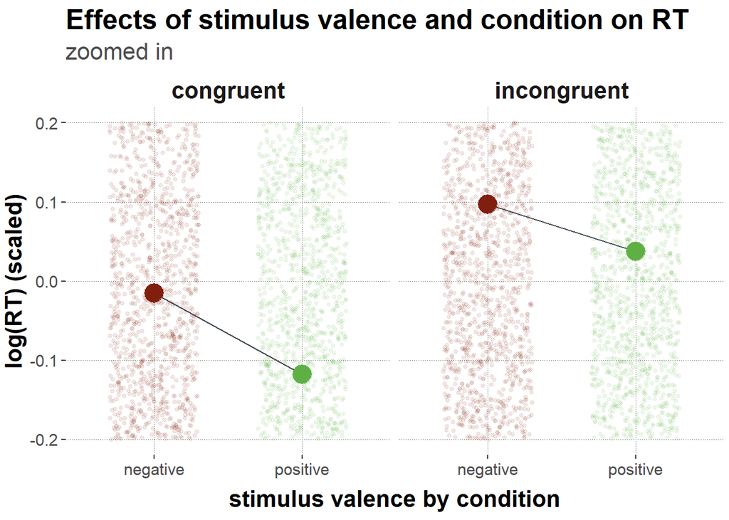

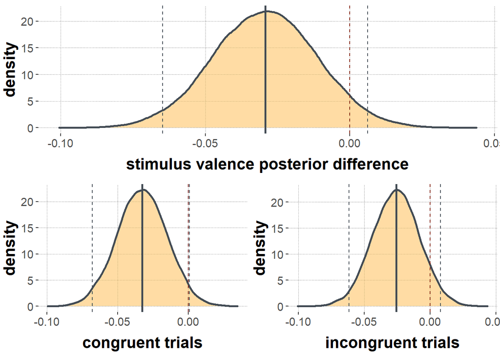

The difference in reaction times does not seem to depend on condition.

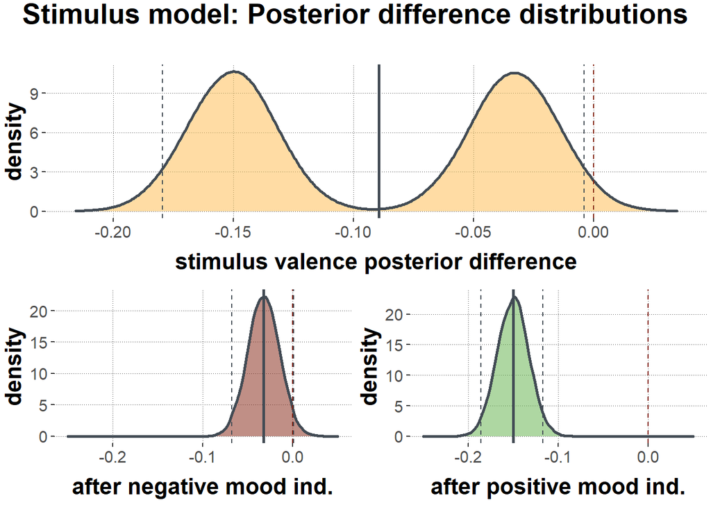

```
## # A tibble: 3 x 4
##   posteriors                               median CrI_lower CrI_upper
##   <chr>                                     <dbl>     <dbl>     <dbl>
## 1 valence difference                       -22.2      -44.4    -0.860
## 2 difference after negative mood induction  -8.11     -16.7     0.280
## 3 difference after positive mood induction -37.0      -45.9   -28.5
```

The difference seems to depend on the mood induction condition. Especially in the positive mood induction condition, the reaction times are shorter for positive than for negative stimuli.

```
## [1] "valence difference regardless of condition:"
```

```
## Summary of Posterior Distribution
##
## Parameter | Median |         95% CI |     pd |          ROPE | % in ROPE
## ------------------------------------------------------------------------
## posterior |  -0.09 | [-0.18,  0.00] | 98.48% | [-0.10, 0.10] |    50.09%
```

```
## [1] "valence difference after negative mood induction:"
```

```
## Summary of Posterior Distribution
##
## Parameter | Median |        95% CI |     pd |          ROPE | % in ROPE
## -----------------------------------------------------------------------
## posterior |  -0.03 | [-0.07, 0.00] | 96.97% | [-0.10, 0.10] |      100%
```

```
## [1] "valence difference after positive mood induction:"
```

```
## Summary of Posterior Distribution
##
## Parameter | Median |         95% CI |   pd |          ROPE | % in ROPE
## ----------------------------------------------------------------------
## posterior |  -0.15 | [-0.19, -0.12] | 100% | [-0.10, 0.10] |        0%
```

```r
describe_posterior(fit_stimulusModelInt, centrality = "median", ci = 0.95, ci_method = "hdi", test = c("p_direction"))
```

```
## Summary of Posterior Distribution
##
## Parameter                                                            |   Median |         95% CI |     pd |  Rhat |      ESS
## ----------------------------------------------------------------------------------------------------------------------------
## (Intercept)                                                          |    -0.02 | [-0.15,  0.12] | 60.27% | 1.001 |  1568.00
## conditionincongruent                                                 |     0.14 | [ 0.08,  0.21] | 99.98% | 1.000 |  8688.00
## mood_inductionpositive                                               |     0.04 | [-0.06,  0.14] | 76.98% | 1.000 |  4044.00
## stimulus_valencepositive                                             |    -0.03 | [-0.07,  0.00] | 96.97% | 1.000 | 17513.00
## conditionincongruent:mood_inductionpositive                          |    -0.06 | [-0.13,  0.02] | 93.56% | 1.000 | 13279.00
## conditionincongruent:stimulus_valencepositive                        | 6.80e-03 | [-0.04,  0.06] | 60.90% | 1.000 | 17215.00
## mood_inductionpositive:stimulus_valencepositive                      |    -0.12 | [-0.17, -0.07] |   100% | 1.000 | 17746.00
## conditionincongruent:mood_inductionpositive:stimulus_valencepositive |     0.07 | [ 0.00,  0.14] | 96.71% | 1.000 | 16751.00
```

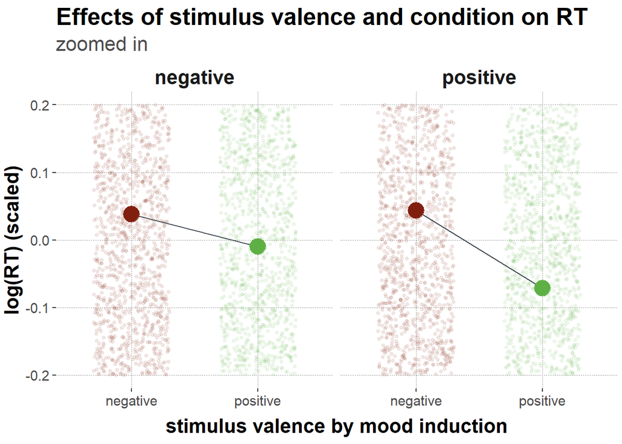

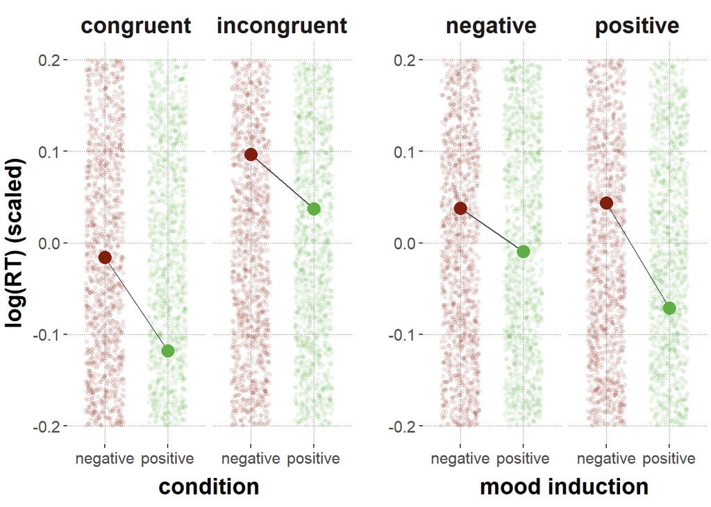

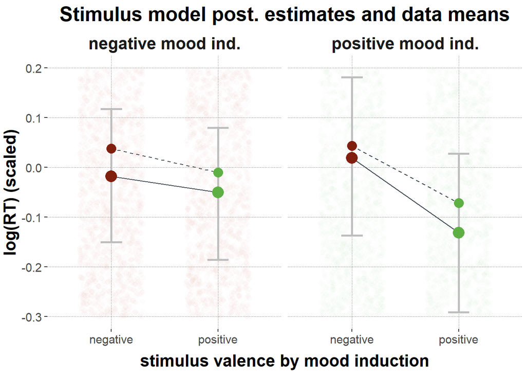

```r
# difference between reaction times for the different valences?

# SHORTER! reaction times for positive than for negative stimuli in the congruent condition after Negind
hypothesis(fit_stimulusModelInt, 'Intercept + stimulus_valencepositive < Intercept')
```

```
## Hypothesis Tests for class b:
##                 Hypothesis Estimate Est.Error CI.Lower CI.Upper Evid.Ratio
## 1 (Intercept+stimul... < 0    -0.03      0.02    -0.06        0      31.95
##   Post.Prob Star
## 1      0.97    *
## ---
## 'CI': 90%-CI for one-sided and 95%-CI for two-sided hypotheses.
## '*': For one-sided hypotheses, the posterior probability exceeds 95%;
## for two-sided hypotheses, the value tested against lies outside the 95%-CI.
## Posterior probabilities of point hypotheses assume equal prior probabilities.
```

```r
# SHORTER reaction times for positive than for negative in the incongruent condition after Negind
hypothesis(fit_stimulusModelInt, 'Intercept + stimulus_valencepositive + conditionincongruent + conditionincongruent:stimulus_valencepositive < Intercept + conditionincongruent')
```

```
## Hypothesis Tests for class b:
##                 Hypothesis Estimate Est.Error CI.Lower CI.Upper Evid.Ratio
## 1 (Intercept+stimul... < 0    -0.03      0.02    -0.06        0      12.83
##   Post.Prob Star
## 1      0.93
## ---
## 'CI': 90%-CI for one-sided and 95%-CI for two-sided hypotheses.
## '*': For one-sided hypotheses, the posterior probability exceeds 95%;
## for two-sided hypotheses, the value tested against lies outside the 95%-CI.
## Posterior probabilities of point hypotheses assume equal prior probabilities.
```

```r
# after positive Mood ind:
# congruent: LARGEST ESTIMATE!
hypothesis(fit_stimulusModelInt, 'Intercept + stimulus_valencepositive + mood_inductionpositive + mood_inductionpositive:stimulus_valencepositive < Intercept + mood_inductionpositive')
```

```
## Hypothesis Tests for class b:
##                 Hypothesis Estimate Est.Error CI.Lower CI.Upper Evid.Ratio
## 1 (Intercept+stimul... < 0    -0.15      0.02    -0.18    -0.12        Inf
##   Post.Prob Star
## 1         1    *
## ---
## 'CI': 90%-CI for one-sided and 95%-CI for two-sided hypotheses.
## '*': For one-sided hypotheses, the posterior probability exceeds 95%;
## for two-sided hypotheses, the value tested against lies outside the 95%-CI.
## Posterior probabilities of point hypotheses assume equal prior probabilities.
```

```r
# incongruent:
hypothesis(fit_stimulusModelInt, 'Intercept + stimulus_valencepositive + mood_inductionpositive + mood_inductionpositive:stimulus_valencepositive + conditionincongruent + conditionincongruent:mood_inductionpositive + conditionincongruent:stimulus_valencepositive + conditionincongruent:mood_inductionpositive:stimulus_valencepositive < Intercept + mood_inductionpositive + conditionincongruent + conditionincongruent:mood_inductionpositive')
```

```
## Hypothesis Tests for class b:
##                 Hypothesis Estimate Est.Error CI.Lower CI.Upper Evid.Ratio
## 1 (Intercept+stimul... < 0    -0.08      0.02    -0.11    -0.05        Inf
##   Post.Prob Star
## 1         1    *
## ---
## 'CI': 90%-CI for one-sided and 95%-CI for two-sided hypotheses.
## '*': For one-sided hypotheses, the posterior probability exceeds 95%;
## for two-sided hypotheses, the value tested against lies outside the 95%-CI.
## Posterior probabilities of point hypotheses assume equal prior probabilities.
```

Usually, I’d expect reaction times in response to negative stimuli to be smaller than reaction times in response to positive stimuli. Here, the exact opposite seems to be the case.

#### Comparing with data from previous experiment:

```r
df_AAT_raw = read.csv("rohdaten_johannes.csv")
load("affect-aat-raw-data.Rdata")
```

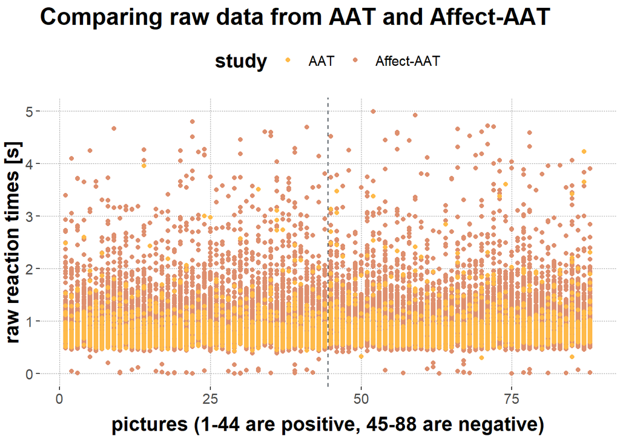

```
## # A tibble: 4 x 3
## # Groups:   study [2]
##   study      stimulus_valence  mean
##   <chr>      <chr>            <dbl>
## 1 AAT        negative         0.880
## 2 AAT        positive         0.821
## 3 Affect-AAT negative         0.938
## 4 Affect-AAT positive         0.908
```